# Metric Graph Low-Pass: Path-Graph Multi-Method 1D Benchmark

## 1 Purpose

This report compares `fit.metric.graph.lowpass()` against established 1D nonlinear regression methods, graph-signal denoising methods, and `fit.rdgraph.regression()` on the curated 240-dataset Gaussian-mixture benchmark.

The graph-based methods use the sorted 1D path graph. Vertices are ordered by sample coordinate $x_i$, adjacent ordered samples are connected, and edge lengths are adjacent spacings:

$$\ell_i = x_{(i+1)} - x_{(i)}.$$

The metric low-pass sweep transforms these lengths into conductances:

$$c_{ij} = (\ell_{ij} + \epsilon)^{-\alpha},
\qquad
c_{ij} = \exp(-\ell_{ij}/\sigma),$$

$$c_{ij} = \exp(-\ell_{ij}^{2}/\sigma^{2}),
\qquad
c_{ij} = \exp\{-\ell_{ij}^{2}/(\sigma_i\sigma_j)\}.$$

`GSD::gsmoothing()` and `gasper` SGWT/SURE denoising receive a path-graph conductance adjacency built with the same metric-length interpretation, using `exp.length` with `sigma=edge.q0.75`.

## 2 Load Results

```r
results.file <- file.path(
  repo.dir,
  "dev/metric-graph-lowpass-benchmarks/reports/multi_method_path_1d_mixture_results.csv"
)
if (!file.exists(results.file)) {
  stop("Missing precomputed results file. Run compute_multi_method_path_1d_mixture_results.R first.")
}
results <- read.csv(results.file, stringsAsFactors = FALSE)

data.frame(
  n.rows = nrow(results),
  n.datasets = length(unique(results$dataset.id)),
  n.estimators = length(unique(results$config.label)),
  n.errors = sum(results$status != "ok"),
  results.file = results.file
)
```

```
##   n.rows n.datasets n.estimators n.errors
## 1   4800        240           20        0
##                                                                                                                results.file
## 1 /Users/pgajer/current_projects/gflow/dev/metric-graph-lowpass-benchmarks/reports/multi_method_path_1d_mixture_results.csv
```

```r
ok <- subset(results, status == "ok")
ok$estimator <- ok$config.label
ok$log.rmse.truth <- log(ok$rmse.truth)
ok$display.family <- factor(
  ok$method.family,
  levels = c("metric low-pass", "classical 1D", "graph denoising", "rdgraph")
)

estimator.summary <- aggregate(
  rmse.truth ~ estimator + method + method.family,
  data = ok,
  FUN = function(z) c(median = median(z), mean = mean(z),
                      q90 = unname(quantile(z, 0.90)))
)
estimator.summary <- do.call(data.frame, estimator.summary)
names(estimator.summary) <- sub("rmse.truth.", "", names(estimator.summary), fixed = TRUE)
estimator.summary <- estimator.summary[order(estimator.summary$median), ]
best.estimator <- estimator.summary$estimator[1]
rdgraph.estimator <- "fit.rdgraph.regression.path"

head(estimator.summary, 20)
```

```
##                              estimator                   method   method.family
## 1              genlasso.trendfilter.cv  genlasso.trendfilter.cv    classical 1D
## 5                    smooth.spline.gcv        smooth.spline.gcv    classical 1D
## 3                        mgcv.gam.reml            mgcv.gam.reml    classical 1D
## 4                          np.npreg.cv              np.npreg.cv    classical 1D
## 2                            loess.gcv                loess.gcv    classical 1D
## 13        inverse.length.power alpha=1 fit.metric.graph.lowpass metric low-pass
## 14      inverse.length.power alpha=1.5 fit.metric.graph.lowpass metric low-pass
## 8          exp.length sigma=edge.q0.75 fit.metric.graph.lowpass metric low-pass
## 15        inverse.length.power alpha=2 fit.metric.graph.lowpass metric low-pass
## 12      inverse.length.power alpha=0.5 fit.metric.graph.lowpass metric low-pass
## 9              exp.length sigma=median fit.metric.graph.lowpass metric low-pass
## 17      self.tuned.gaussian local.k=10 fit.metric.graph.lowpass metric low-pass
## 18       self.tuned.gaussian local.k=3 fit.metric.graph.lowpass metric low-pass
## 19       self.tuned.gaussian local.k=5 fit.metric.graph.lowpass metric low-pass
```

[output cut: 27 more lines]

## 3 Overall Performance

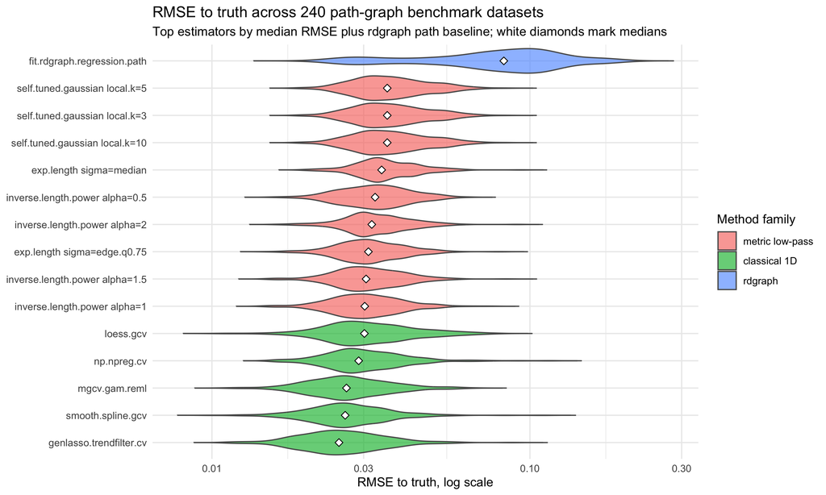

```r
top.estimators <- head(estimator.summary$estimator, 14)
plot.df <- subset(ok, estimator %in% unique(c(top.estimators, rdgraph.estimator)))
plot.df$estimator <- factor(
  plot.df$estimator,
  levels = estimator.summary$estimator[estimator.summary$estimator %in% unique(plot.df$estimator)]
)

ggplot(plot.df, aes(x = estimator, y = rmse.truth, fill = display.family)) +
  geom_violin(scale = "width", trim = FALSE, alpha = 0.65, color = "gray35") +
  stat_summary(fun = median, geom = "point", shape = 23, size = 2.2,
               fill = "white", color = "black") +
  scale_y_log10() +
  coord_flip() +
  labs(
    title = "RMSE to truth across 240 path-graph benchmark datasets",
    subtitle = "Top estimators by median RMSE plus rdgraph path baseline; white diamonds mark medians",
    x = NULL,
    y = "RMSE to truth, log scale",
    fill = "Method family"
  ) +
  theme_minimal(base_size = 11)
```

```r
family.summary <- aggregate(
  rmse.truth ~ method.family,
  data = ok,
  FUN = function(z) c(median = median(z), q25 = unname(quantile(z, 0.25)),
                      q75 = unname(quantile(z, 0.75)), mean = mean(z))
)
do.call(data.frame, family.summary)
```

```
##     method.family rmse.truth.median rmse.truth.q25 rmse.truth.q75
## 1    classical 1D        0.02736902     0.02304871     0.03382655
## 2 graph denoising        0.06551319     0.05471225     0.08152269
## 3 metric low-pass        0.03463503     0.02939884     0.04217329
## 4         rdgraph        0.08277186     0.05723411     0.10796547
##   rmse.truth.mean
## 1      0.02950986
## 2      0.08423713
## 3      0.03709622
## 4      0.08424977
```

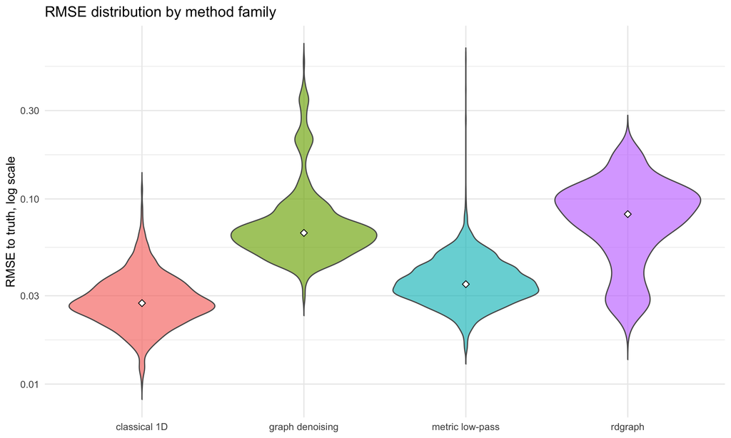

```r
ggplot(ok, aes(x = method.family, y = rmse.truth, fill = method.family)) +
  geom_violin(scale = "width", trim = FALSE, alpha = 0.65, color = "gray35") +
  stat_summary(fun = median, geom = "point", shape = 23, size = 2.2,
               fill = "white", color = "black") +
  scale_y_log10() +
  labs(
    title = "RMSE distribution by method family",
    x = NULL,
    y = "RMSE to truth, log scale"
  ) +
  theme_minimal(base_size = 12) +
  theme(legend.position = "none")
```

## 4 Per-Dataset Winners

```r
best.by.dataset <- ok[order(ok$dataset.id, ok$rmse.truth), ]
best.by.dataset <- best.by.dataset[!duplicated(best.by.dataset$dataset.id), ]

winner.table <- sort(table(best.by.dataset$estimator), decreasing = TRUE)
head(data.frame(estimator = names(winner.table), wins = as.integer(winner.table)), 20)
```

```
##                         estimator wins
## 1         genlasso.trendfilter.cv  130
## 2                   mgcv.gam.reml   42
## 3               smooth.spline.gcv   36
## 4                       loess.gcv   10
## 5                     np.npreg.cv    8
## 6    inverse.length.power alpha=1    7
## 7     exp.length sigma=edge.q0.75    2
## 8  inverse.length.power alpha=1.5    2
## 9    inverse.length.power alpha=3    2
## 10   inverse.length.power alpha=2    1
```

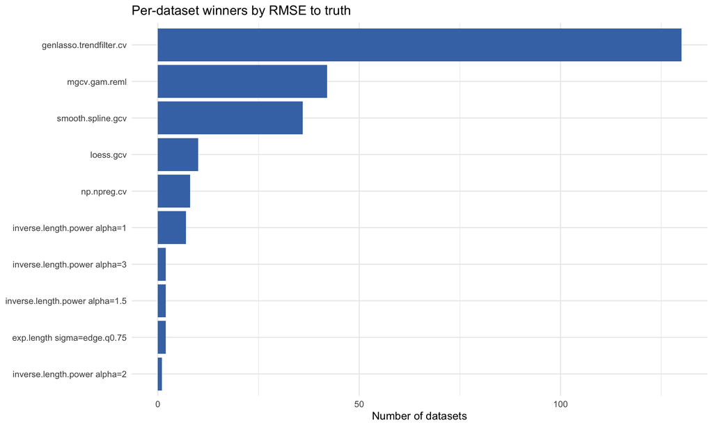

```r
winner.df <- head(data.frame(estimator = names(winner.table),
                             wins = as.integer(winner.table)), 15)
ggplot(winner.df, aes(x = reorder(estimator, wins), y = wins)) +
  geom_col(fill = "#4575b4") +
  coord_flip() +
  labs(
    title = "Per-dataset winners by RMSE to truth",
    x = NULL,
    y = "Number of datasets"
  ) +
  theme_minimal(base_size = 11)
```

## 5 Frequentist Paired Comparisons

```r
paired_comparisons <- function(dat, reference.estimator) {
  estimators <- sort(unique(dat$estimator))
  ref <- dat[dat$estimator == reference.estimator, c("dataset.id", "log.rmse.truth")]
  names(ref)[2] <- "ref.log.rmse"
  out <- lapply(estimators[estimators != reference.estimator], function(est) {
    cur <- dat[dat$estimator == est, c("dataset.id", "log.rmse.truth")]
    names(cur)[2] <- "cur.log.rmse"
    m <- merge(ref, cur, by = "dataset.id")
    d <- m$cur.log.rmse - m$ref.log.rmse
    tt <- stats::t.test(d, mu = 0)
    wt <- stats::wilcox.test(d, mu = 0, exact = FALSE)
    data.frame(
      estimator = est,
      reference = reference.estimator,
      n = length(d),
      mean.log.rmse.diff = mean(d),
      conf.low = unname(tt$conf.int[1]),
      conf.high = unname(tt$conf.int[2]),
      median.log.rmse.diff = median(d),
      ratio.from.mean = exp(mean(d)),
      ratio.conf.low = exp(unname(tt$conf.int[1])),
      ratio.conf.high = exp(unname(tt$conf.int[2])),
      t.p.value = tt$p.value,
      wilcox.p.value = wt$p.value,
      stringsAsFactors = FALSE
    )
  })
  out <- do.call(rbind, out)
  out$t.p.adj.bh <- p.adjust(out$t.p.value, method = "BH")
  out$wilcox.p.adj.bh <- p.adjust(out$wilcox.p.value, method = "BH")
  out[order(out$mean.log.rmse.diff), ]
}

freq.vs.rdgraph <- paired_comparisons(ok, rdgraph.estimator)
freq.vs.best <- paired_comparisons(ok, best.estimator)
```

Negative log-RMSE differences mean the estimator has lower RMSE than the reference.

```r
head(freq.vs.rdgraph, 20)
```

```
##                              estimator                   reference   n
## 6              genlasso.trendfilter.cv fit.rdgraph.regression.path 240
## 19                   smooth.spline.gcv fit.rdgraph.regression.path 240
## 14                       mgcv.gam.reml fit.rdgraph.regression.path 240
## 15                         np.npreg.cv fit.rdgraph.regression.path 240
## 9         inverse.length.power alpha=1 fit.rdgraph.regression.path 240
## 13                           loess.gcv fit.rdgraph.regression.path 240
## 10      inverse.length.power alpha=1.5 fit.rdgraph.regression.path 240
## 1          exp.length sigma=edge.q0.75 fit.rdgraph.regression.path 240
## 8       inverse.length.power alpha=0.5 fit.rdgraph.regression.path 240
## 11        inverse.length.power alpha=2 fit.rdgraph.regression.path 240
## 2              exp.length sigma=median fit.rdgraph.regression.path 240
## 16      self.tuned.gaussian local.k=10 fit.rdgraph.regression.path 240
## 17       self.tuned.gaussian local.k=3 fit.rdgraph.regression.path 240
## 18       self.tuned.gaussian local.k=5 fit.rdgraph.regression.path 240
```

[output cut: 65 more lines]

```r
head(freq.vs.best, 20)
```

```
##                              estimator               reference   n
## 19                   smooth.spline.gcv genlasso.trendfilter.cv 240
## 14                       mgcv.gam.reml genlasso.trendfilter.cv 240
## 15                         np.npreg.cv genlasso.trendfilter.cv 240
## 9         inverse.length.power alpha=1 genlasso.trendfilter.cv 240
## 13                           loess.gcv genlasso.trendfilter.cv 240
## 10      inverse.length.power alpha=1.5 genlasso.trendfilter.cv 240
## 1          exp.length sigma=edge.q0.75 genlasso.trendfilter.cv 240
## 8       inverse.length.power alpha=0.5 genlasso.trendfilter.cv 240
## 11        inverse.length.power alpha=2 genlasso.trendfilter.cv 240
## 2              exp.length sigma=median genlasso.trendfilter.cv 240
## 16      self.tuned.gaussian local.k=10 genlasso.trendfilter.cv 240
## 17       self.tuned.gaussian local.k=3 genlasso.trendfilter.cv 240
## 18       self.tuned.gaussian local.k=5 genlasso.trendfilter.cv 240
## 3  exp.length.squared sigma=edge.q0.75 genlasso.trendfilter.cv 240
```

[output cut: 65 more lines]

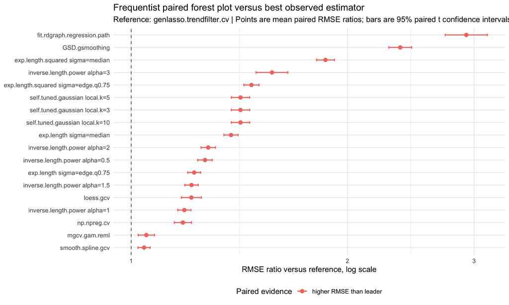

```r
freq.best.plot <- head(freq.vs.best[order(freq.vs.best$ratio.from.mean), ], 18)
freq.best.plot$evidence <- ifelse(
  freq.best.plot$t.p.adj.bh < 0.05 & freq.best.plot$ratio.conf.high < 1,
  "lower RMSE than leader",
  ifelse(freq.best.plot$t.p.adj.bh < 0.05 & freq.best.plot$ratio.conf.low > 1,
         "higher RMSE than leader", "not separated")
)

ggplot(freq.best.plot,
       aes(x = ratio.from.mean, y = reorder(estimator, ratio.from.mean),
           color = evidence)) +
  geom_vline(xintercept = 1, linetype = 2, color = "gray40") +
  geom_errorbarh(aes(xmin = ratio.conf.low, xmax = ratio.conf.high),
                 height = 0.2, linewidth = 0.7) +
  geom_point(size = 2.2) +
  scale_x_log10() +
  labs(
    title = "Frequentist paired forest plot versus best observed estimator",
    subtitle = paste("Reference:", best.estimator,
                     "| Points are mean paired RMSE ratios; bars are 95% paired t confidence intervals"),
    x = "RMSE ratio versus reference, log scale",
    y = NULL,
    color = "Paired evidence"
  ) +
  theme_minimal(base_size = 11) +
  theme(legend.position = "bottom")
```

## 6 Bayesian Paired Comparisons

For a paired comparison, let
$$d_i = \log(\mathrm{RMSE}_{m,i}) - \log(\mathrm{RMSE}_{r,i}).$$

The report uses the standard conjugate/large-sample Bayesian paired-normal summary: the posterior for the mean log-RMSE difference is approximated by a Student $t$ distribution centered at $\bar d$, with scale $s_d/\sqrt{n}$. Lower values are better, so $\Pr(\mu_d < 0)$ is the posterior probability that method $m$ beats the reference on mean log-RMSE.

```r
bayes_paired_comparisons <- function(dat, reference.estimator) {
  estimators <- sort(unique(dat$estimator))
  ref <- dat[dat$estimator == reference.estimator, c("dataset.id", "log.rmse.truth")]
  names(ref)[2] <- "ref.log.rmse"
  out <- lapply(estimators[estimators != reference.estimator], function(est) {
    cur <- dat[dat$estimator == est, c("dataset.id", "log.rmse.truth")]
    names(cur)[2] <- "cur.log.rmse"
    m <- merge(ref, cur, by = "dataset.id")
    d <- m$cur.log.rmse - m$ref.log.rmse
    n <- length(d)
    mu <- mean(d)
    se <- stats::sd(d) / sqrt(n)
    df <- n - 1L
    qs <- mu + se * stats::qt(c(0.025, 0.50, 0.975), df = df)
    data.frame(
      estimator = est,
      reference = reference.estimator,
      n = n,
      posterior.mean.log.diff = mu,
      posterior.median.log.diff = qs[2],
      cred.low = qs[1],
      cred.high = qs[3],
      posterior.prob.beats.reference = stats::pt((0 - mu) / se, df = df),
      posterior.mean.rmse.ratio = exp(mu),
      ratio.cred.low = exp(qs[1]),
      ratio.cred.high = exp(qs[3]),
      stringsAsFactors = FALSE
    )
  })
  out <- do.call(rbind, out)
  out[order(-out$posterior.prob.beats.reference, out$posterior.mean.log.diff), ]
}

bayes.vs.rdgraph <- bayes_paired_comparisons(ok, rdgraph.estimator)
bayes.vs.best <- bayes_paired_comparisons(ok, best.estimator)
```

```r
head(bayes.vs.rdgraph, 20)
```

```
##                              estimator                   reference   n
## 6              genlasso.trendfilter.cv fit.rdgraph.regression.path 240
## 19                   smooth.spline.gcv fit.rdgraph.regression.path 240
## 14                       mgcv.gam.reml fit.rdgraph.regression.path 240
## 15                         np.npreg.cv fit.rdgraph.regression.path 240
## 9         inverse.length.power alpha=1 fit.rdgraph.regression.path 240
## 13                           loess.gcv fit.rdgraph.regression.path 240
## 10      inverse.length.power alpha=1.5 fit.rdgraph.regression.path 240
## 1          exp.length sigma=edge.q0.75 fit.rdgraph.regression.path 240
## 8       inverse.length.power alpha=0.5 fit.rdgraph.regression.path 240
## 11        inverse.length.power alpha=2 fit.rdgraph.regression.path 240
## 2              exp.length sigma=median fit.rdgraph.regression.path 240
## 16      self.tuned.gaussian local.k=10 fit.rdgraph.regression.path 240
## 17       self.tuned.gaussian local.k=3 fit.rdgraph.regression.path 240
## 18       self.tuned.gaussian local.k=5 fit.rdgraph.regression.path 240
```

[output cut: 65 more lines]

```r
head(bayes.vs.best, 20)
```

```
##                              estimator               reference   n
## 14                       mgcv.gam.reml genlasso.trendfilter.cv 240
## 19                   smooth.spline.gcv genlasso.trendfilter.cv 240
## 13                           loess.gcv genlasso.trendfilter.cv 240
## 15                         np.npreg.cv genlasso.trendfilter.cv 240
## 9         inverse.length.power alpha=1 genlasso.trendfilter.cv 240
## 12        inverse.length.power alpha=3 genlasso.trendfilter.cv 240
## 10      inverse.length.power alpha=1.5 genlasso.trendfilter.cv 240
## 1          exp.length sigma=edge.q0.75 genlasso.trendfilter.cv 240
## 8       inverse.length.power alpha=0.5 genlasso.trendfilter.cv 240
## 11        inverse.length.power alpha=2 genlasso.trendfilter.cv 240
## 16      self.tuned.gaussian local.k=10 genlasso.trendfilter.cv 240
## 17       self.tuned.gaussian local.k=3 genlasso.trendfilter.cv 240
## 18       self.tuned.gaussian local.k=5 genlasso.trendfilter.cv 240
## 2              exp.length sigma=median genlasso.trendfilter.cv 240
```

[output cut: 65 more lines]

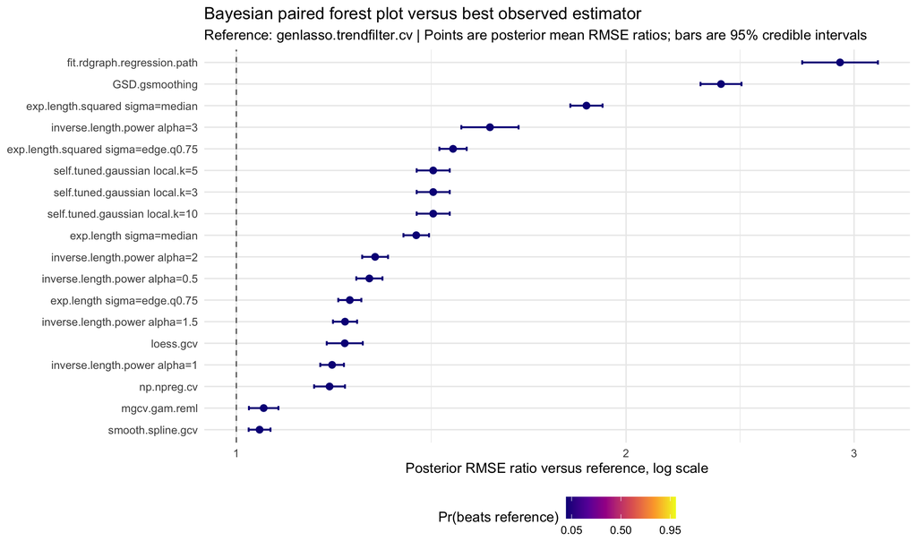

```r
bayes.best.plot <- head(
  bayes.vs.best[order(bayes.vs.best$posterior.mean.rmse.ratio), ],
  18
)
bayes.best.plot$prob.label <- cut(
  bayes.best.plot$posterior.prob.beats.reference,
  breaks = c(-Inf, 0.05, 0.50, 0.95, Inf),
  labels = c("< 0.05", "0.05-0.50", "0.50-0.95", "> 0.95")
)

ggplot(bayes.best.plot,
       aes(x = posterior.mean.rmse.ratio,
           y = reorder(estimator, posterior.mean.rmse.ratio),
           color = posterior.prob.beats.reference)) +
  geom_vline(xintercept = 1, linetype = 2, color = "gray40") +
  geom_errorbarh(aes(xmin = ratio.cred.low, xmax = ratio.cred.high),
                 height = 0.2, linewidth = 0.7) +
  geom_point(size = 2.2) +
  scale_x_log10() +
  scale_color_viridis_c(
    option = "C",
    limits = c(0, 1),
    breaks = c(0.05, 0.50, 0.95),
    labels = c("0.05", "0.50", "0.95")
  ) +
  labs(
    title = "Bayesian paired forest plot versus best observed estimator",
    subtitle = paste("Reference:", best.estimator,
                     "| Points are posterior mean RMSE ratios; bars are 95% credible intervals"),
    x = "Posterior RMSE ratio versus reference, log scale",
    y = NULL,
    color = "Pr(beats reference)"
  ) +
  theme_minimal(base_size = 11) +
  theme(legend.position = "bottom")
```

## 7 Bayesian Bootstrap Ranking

```r
bayesian_bootstrap_ranks <- function(dat, B = 4000L, seed = 53191L) {
  common.datasets <- Reduce(intersect, split(dat$dataset.id, dat$estimator))
  dat <- dat[dat$dataset.id %in% common.datasets, ]
  estimators <- sort(unique(dat$estimator))
  y <- matrix(NA_real_, nrow = length(common.datasets), ncol = length(estimators),
              dimnames = list(common.datasets, estimators))
  for (j in seq_along(estimators)) {
    cur <- dat[dat$estimator == estimators[j], c("dataset.id", "log.rmse.truth")]
    y[cur$dataset.id, j] <- cur$log.rmse.truth
  }
  keep <- stats::complete.cases(y)
  y <- y[keep, , drop = FALSE]
  set.seed(seed)
  ranks <- matrix(NA_integer_, nrow = B, ncol = ncol(y),
                  dimnames = list(NULL, colnames(y)))
  for (b in seq_len(B)) {
    w <- stats::rexp(nrow(y))
    w <- w / sum(w)
    means <- as.numeric(crossprod(w, y))
    ranks[b, ] <- rank(means, ties.method = "average")
  }
  data.frame(
    estimator = colnames(y),
    posterior.prob.best = colMeans(ranks == 1),
    posterior.mean.rank = colMeans(ranks),
    posterior.median.rank = apply(ranks, 2, median),
    rank.q95 = apply(ranks, 2, quantile, 0.95),
    stringsAsFactors = FALSE
  )
}

rank.posterior <- bayesian_bootstrap_ranks(ok)
rank.posterior <- merge(rank.posterior,
                        estimator.summary[, c("estimator", "method.family", "median")],
                        by = "estimator", all.x = TRUE)
rank.posterior <- rank.posterior[order(-rank.posterior$posterior.prob.best,
                                       rank.posterior$posterior.mean.rank), ]
head(rank.posterior, 20)
```

```
##                              estimator posterior.prob.best posterior.mean.rank
## 7              genlasso.trendfilter.cv             0.99925             1.00075
## 15                       mgcv.gam.reml             0.00075             2.73725
## 20                   smooth.spline.gcv             0.00000             2.26200
## 16                         np.npreg.cv             0.00000             4.42200
## 10        inverse.length.power alpha=1             0.00000             4.71875
## 11      inverse.length.power alpha=1.5             0.00000             6.54625
## 14                           loess.gcv             0.00000             6.60725
## 1          exp.length sigma=edge.q0.75             0.00000             7.70975
## 9       inverse.length.power alpha=0.5             0.00000             9.13150
## 12        inverse.length.power alpha=2             0.00000             9.86450
## 2              exp.length sigma=median             0.00000            11.01950
## 17      self.tuned.gaussian local.k=10             0.00000            12.99925
## 18       self.tuned.gaussian local.k=3             0.00000            12.99925
## 19       self.tuned.gaussian local.k=5             0.00000            12.99925
```

[output cut: 27 more lines]

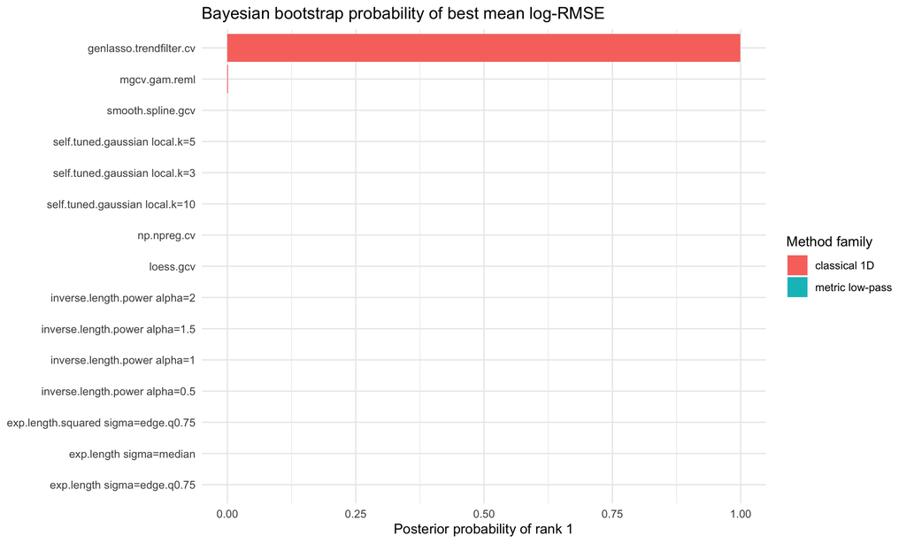

```r
rank.plot <- head(rank.posterior, 15)
ggplot(rank.plot, aes(x = reorder(estimator, posterior.prob.best),
                      y = posterior.prob.best, fill = method.family)) +
  geom_col() +
  coord_flip() +
  labs(
    title = "Bayesian bootstrap probability of best mean log-RMSE",
    x = NULL,
    y = "Posterior probability of rank 1",
    fill = "Method family"
  ) +
  theme_minimal(base_size = 11)
```

## 8 Shape and Noise Effects

```r
shape.variant <- aggregate(
  rmse.truth ~ shape.id + shape.name + variant.id + variant.name + estimator + method.family,
  data = ok,
  FUN = median
)
shape.variant.best <- shape.variant[order(shape.variant$shape.id, shape.variant$variant.id,
                                          shape.variant$rmse.truth), ]
shape.variant.best <- shape.variant.best[!duplicated(paste(shape.variant.best$shape.id,
                                                           shape.variant.best$variant.id)), ]
shape.variant.best[, c("shape.id", "variant.id", "estimator", "method.family", "rmse.truth")]
```

```
##     shape.id variant.id               estimator method.family rmse.truth
## 239      S01         V1       smooth.spline.gcv  classical 1D 0.02489369
## 111      S01         V2           mgcv.gam.reml  classical 1D 0.03018622
## 223      S01         V3       smooth.spline.gcv  classical 1D 0.03058883
## 48       S02         V1 genlasso.trendfilter.cv  classical 1D 0.01781672
## 16       S02         V2 genlasso.trendfilter.cv  classical 1D 0.01904876
## 224      S02         V3       smooth.spline.gcv  classical 1D 0.03241680
## 44       S03         V1 genlasso.trendfilter.cv  classical 1D 0.01866367
## 204      S03         V2       smooth.spline.gcv  classical 1D 0.02009059
## 124      S03         V3           mgcv.gam.reml  classical 1D 0.03064694
## 45       S04         V1 genlasso.trendfilter.cv  classical 1D 0.01799665
## 13       S04         V2 genlasso.trendfilter.cv  classical 1D 0.02304982
## 29       S04         V3 genlasso.trendfilter.cv  classical 1D 0.02108383
## 41       S05         V1 genlasso.trendfilter.cv  classical 1D 0.02052747
## 105      S05         V2           mgcv.gam.reml  classical 1D 0.02028838
```

[output cut: 34 more lines]

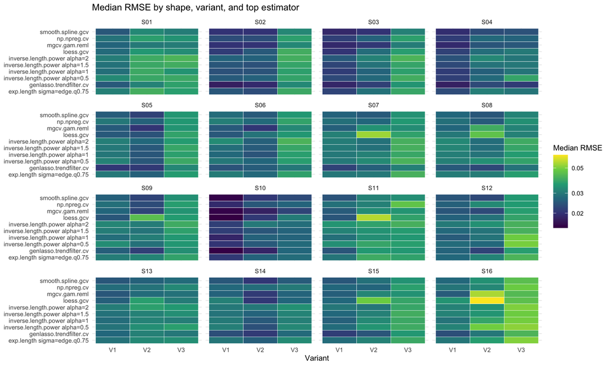

```r
top.for.heatmap <- head(estimator.summary$estimator, 10)
heat.df <- subset(shape.variant, estimator %in% top.for.heatmap)
ggplot(heat.df, aes(x = variant.id, y = estimator, fill = rmse.truth)) +
  geom_tile(color = "white") +
  facet_wrap(~ shape.id, ncol = 4) +
  scale_fill_viridis_c(trans = "log10") +
  labs(
    title = "Median RMSE by shape, variant, and top estimator",
    x = "Variant",
    y = NULL,
    fill = "Median RMSE"
  ) +
  theme_minimal(base_size = 9)
```

## 9 Runtime and Failures

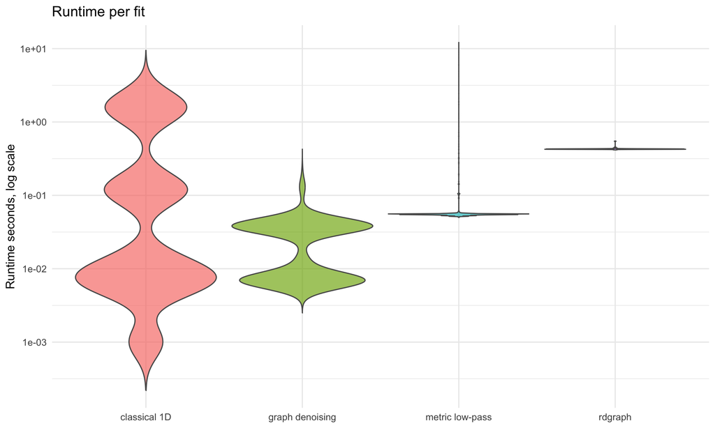

```r
ggplot(ok, aes(x = method.family, y = runtime.sec, fill = method.family)) +
  geom_violin(scale = "width", trim = FALSE, alpha = 0.65, color = "gray35") +
  scale_y_log10() +
  labs(
    title = "Runtime per fit",
    x = NULL,
    y = "Runtime seconds, log scale"
  ) +
  theme_minimal(base_size = 12) +
  theme(legend.position = "none")
```

```r
failure.table <- subset(results, status != "ok")
if (nrow(failure.table) == 0) {
  data.frame(message = "No fit failures")
} else {
  aggregate(dataset.id ~ method + config.label + message,
            data = failure.table, FUN = length)
}
```

```
##           message
## 1 No fit failures
```

## 10 Result Location

```r
results.file
```

```
## [1] "/Users/pgajer/current_projects/gflow/dev/metric-graph-lowpass-benchmarks/reports/multi_method_path_1d_mixture_results.csv"
```